# R Steinschlag_Datavisualization

In this R notebook I’m going to explore the data of the “Steinschlag-Challeng, HS19C4”. The Idea behind the project is to calculate the probablilty of a death through a rockfall at a slope above a road in Graubünden, Switzerland. The Challenge itself can be found under the following link: [Steinschlag Challenge](https://ds-spaces.technik.fhnw.ch/steinschlag/)

This notebook is used to visualize the data through numerous plots. The calculation of the probability is made in a Python-Notebook and the final findings of this exploration will be published later on a website.

```
[1] "C:/Users/Roman Studer/Dropbox/01_SG DS/Challenges/Steinschlag/Steinschlag_git_respository/steinschlag"
```

### 1. Data transformation

#### 1.1 `rename` CSV-Colums and `rbind` CSV’s

```r
out_1 <- rename(out_1, mass = Masse..kg., speed = Geschwindigkeit..m.s., time = Uhrzeit, date = Datum, energy = Kin_Energy..kJ.)
out_2 <- rename(out_2, mass = Masse..kg., speed = Geschwindigkeit..m.s., time = Uhrzeit, date = Datum, energy = Kin_Energy..kJ.)
```

#### 1.2 Transform time column into datetime-type

The code below could be used to transform the time column of our dataset into a datetime type.

```r
# out_1 <- transform(out_1, time = as.times(time))
# out_2 <- transform(out_1, time = as.times(time))
```

#### 1.3 Combine Datasets

```r
#Now that we have two datasets with the same column names we can combine them into one:
data_bind <- rbind(out_1, out_2)
```

#### 1.4 Delete rows with mistakes

In the dataset we see that one event has a mass of zero. Either the rock has a mass below 1 kg or the value is a mistake in the dataset. Because we can’t now what is true I’m going to work with a subset of our original data that doesn’t contain row with a false value:

```r
rockfall <- subset(data_bind, mass != 0)
```

#### 1.5 Data description

```r
mass <- select(rockfall, mass)

description <- describe(select(rockfall, mass, speed, energy))
description
```

|  | vars | n | mean | sd | median | trimmed | mad | min | max | range | skew | kurtosis | se |
| --- | --- | --- | --- | --- | --- | --- | --- | --- | --- | --- | --- | --- | --- |
| mass | 1 | 99 | 463.87 | 628.13 | 236.00 | 327.72 | 263.90 | 3.00 | 3104.0 | 3101.00 | 2.52 | 6.60 | 63.13 |
| speed | 2 | 99 | 17.93 | 14.02 | 10.00 | 16.43 | 4.00 | 3.60 | 46.5 | 42.90 | 0.88 | -1.01 | 1.41 |
| energy | 3 | 99 | 40.45 | 60.39 | 19.06 | 27.05 | 19.68 | 0.46 | 394.8 | 394.33 | 3.39 | 13.73 | 6.07 |

## 2. Datavisualization

### 2.1 Histogramms

#### 2.1.1 Mass

The code below plots a histogramm of the “mass”-column in our dataset. Here we see that most of the rocks have a mass below 500kg. This is intersting because we would need more than four rocks of this size to break through the security-net. If we look at other variables we see that we only have two days with this many rockfalls.(The next histogramms are plottet with the same code, just with other variables)

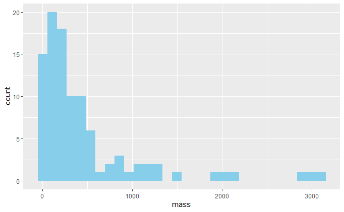

```r
ggplot(data = rockfall)+
  # Plot histogram of the mass distribution in the rochfall dataset:
  geom_histogram(mapping = aes(x =mass), fill = "skyblue")
```

#### 2.1.2 Energy

If we plot the energy (in kilojoule) we can see that a big part of our rocks have a very low energy and we can even see that over 15 have a value of 0 on the plot. This is because we have multiple rocks that don’t reach an energy of >10kJ.

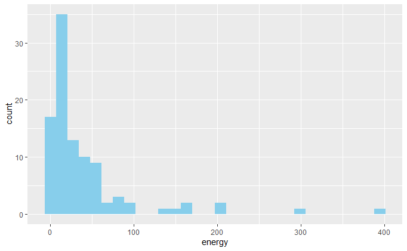

#### 2.1.3 Speed

Here we see that we have a maximum speed of around 46 meters per second. The speed is also split into two groups which indicates shows us the that the two places where rockfalls occur are on a diffrent hight. Later in this notebook I’m going to plot the relationship of the mass and speed.

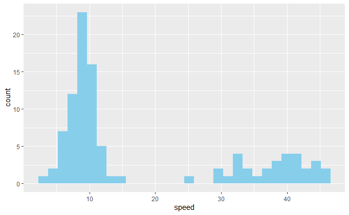

#### 2.1.4 Rockfalls per Hour

As soon as we group the events to the hour they occur we see that we have an increase of rockfalls towards noon and a slower decrease after noon. The most rocks fall at 12 O’clock. At this time the traffic will be high as well, wich means that we should include the traffic density in to our probability calculation.

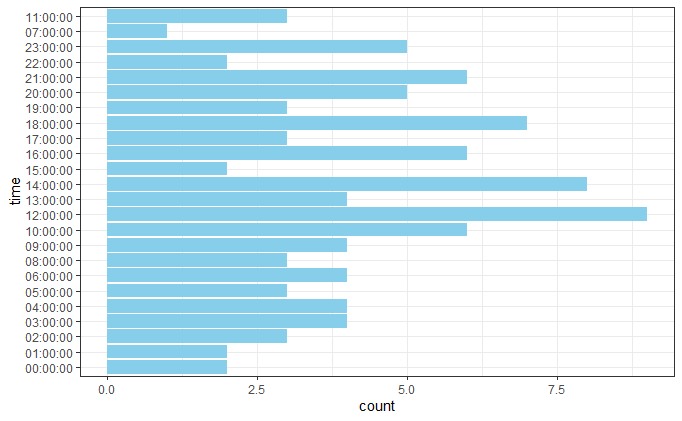

### 2.2 Graphs (`smooth`)

#### 2.2.1 False readouts

Something interesting I found was that the binding of the two datasets can lead to some errors in the datavisualization. The first two graphs below show us how the mass corresponds to the energy of a rockfall. Which seems to be quite linear. This makes sense so far. As soon as we plot the same two variables out of the combined dataset(`rockfall`) we get a spike around 300 to 500 kg. This doesn’t seem to make sense. But this tells us that the rocks of the two dataset have to fall from diffrent hights. Because only a greater speed in one dataset would explain the rise of energy in the mass.

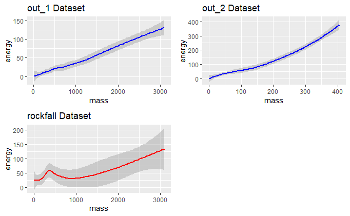

```r
ggplot(data = out_1)+
  geom_smooth(mapping = aes(x = mass, y = energy), color = "blue") + ggtitle("out_1 Dataset") -> p1

ggplot(data = out_2)+
  geom_smooth(mapping = aes(x = mass, y = energy), color = "blue") + ggtitle("out_2 Dataset") -> p2

ggplot(data = rockfall)+
  geom_smooth(mapping = aes(x = mass, y = energy), color = "red") + ggtitle("rockfall Dataset") -> p3
grid.arrange(p1, p2, p3, ncol = 2, nrow = 2)
```

#### 2.2.2 Traffic density per hour

The following graph shows the trafiic density on roads in switzerland per hour. This data will be used to calculate the probability of a hit combined with the traffic density. This data has been pulled from the swiss institute for statistics and contains the information of the average of cars passing through per hour. This dataset is from 2015 but is the latest data with this information.

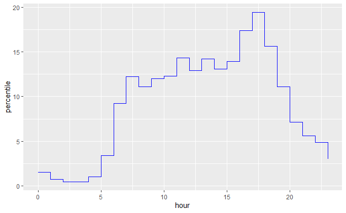

### 2.3 Scatterplot

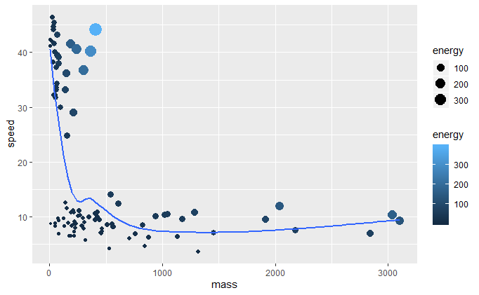

```r
# linie für Energy des Netzes einsetzen , einmal mit Stein im Netz einmal ohne.
ggplot(data = rockfall, aes(x = mass, y = speed, size = energy, color = energy ))+
  geom_point()+
  geom_smooth(se = FALSE, size = 1)
```

### 3. Calculation of the probability of a car getting hit by a rock under the assumption that a rock could break trough the securitynet.

Probability of a brak of the security net within 24 hours.

given: - Rock breaks through net - Mass of stone is over two tonnes - Trafficdensity is 1200 cars per day, without any trafficjam - Speed of the cars: 16.66 m/s - Average size of car: - Length: 4.4m - Width: 1.8m

Assumptions: - Stone is made of granit and has density of 2.7g per cubic kilogramm - Stones have a total volume of 0.75 cubic meters - A car getting hit by stone automaticaly causes a deady accident - Higth of car wont be part of the calculation - Speed of the rock wont be part of the calculation - Width of roch is on average about 1 meter

#### 3.1 Probability of Rockfall per Hour

To calculate the probability at which hour a rockfall takes place I’m going to take a look at the Histogram “Rockfalls per Hour” (2.1.4) which shows me the distribution throughout the day. To count the falls per hour I’m gonna use the function `count` and divide these numbers by 0.99 to get the percentage which also equals the probability of an event occuring at that hour.

| time | n | prob |
| --- | --- | --- |
| 00:00:00 | 2 | 0.02020202 |
| 01:00:00 | 2 | 0.02020202 |
| 02:00:00 | 3 | 0.03030303 |
| 03:00:00 | 4 | 0.04040404 |
| 04:00:00 | 4 | 0.04040404 |
| 05:00:00 | 3 | 0.03030303 |
| 06:00:00 | 4 | 0.04040404 |
| 08:00:00 | 3 | 0.03030303 |
| 09:00:00 | 4 | 0.04040404 |
| 10:00:00 | 6 | 0.06060606 |

[output cut: 14 more lines]

#### 3.2 Total Time a Car is in Danger

The next step is to calculate time a car is in the dangerous zone. We now that the cars drive with 60 km/h and have an average length of 4.4 meters. Because the car can be hit in the front or in the back we need to take double the length plus the width of the stone as our danger zone. Which comes out to be 9.8 meters. With this we calculate the following:

```
Time to drive 9.8m : 0.588 seconds
```

Now that we have the time a car is in the “danger”-zone we can calculate the total time (seconds in day) in which cars are in danger of getting hit by a rock breaking though the net. For this I’m goingt to create a new list called “car_per_hour” which will contain the total count of cars driving through, the total time of cars being in danger and the percentage of a car driving through this zone at this hour.

After that we can calculate the probability of a car getting hit by simply multiplying the probability of a rock falling at this hour and the probability of a car being in the dangerous zone at this hour. We calculate a probability of 0.02006033 or 2.006% for this event to happen.

| time | n | prob | car_per_hour$cars_passing | car_per_hour$time_in_danger | car_per_hour$prob_car | t_p_pro_hour |
| --- | --- | --- | --- | --- | --- | --- |
| 00:00:00 | 2 | 0.02020202 | 18.095611 | 10.640219 | 0.0029556165 | 5.970942e-05 |
| 01:00:00 | 2 | 0.02020202 | 8.546494 | 5.025338 | 0.0013959273 | 2.820055e-05 |
| 02:00:00 | 3 | 0.03030303 | 5.482019 | 3.223427 | 0.0008953964 | 2.713322e-05 |
| 03:00:00 | 4 | 0.04040404 | 5.062038 | 2.976478 | 0.0008267995 | 3.340604e-05 |
| 04:00:00 | 4 | 0.04040404 | 11.763184 | 6.916752 | 0.0019213200 | 7.762909e-05 |
| 05:00:00 | 3 | 0.03030303 | 40.754963 | 23.963918 | 0.0066566439 | 2.017165e-04 |
| 06:00:00 | 4 | 0.04040404 | 110.673258 | 65.075876 | 0.0180766321 | 7.303690e-04 |
| 08:00:00 | 3 | 0.03030303 | 146.934744 | 86.397629 | 0.0239993415 | 7.272528e-04 |
| 09:00:00 | 4 | 0.04040404 | 133.551288 | 78.528157 | 0.0218133770 | 8.813486e-04 |
| 10:00:00 | 6 | 0.06060606 | 144.103128 | 84.732639 | 0.0235368442 | 1.426475e-03 |

[output cut: 14 more lines]

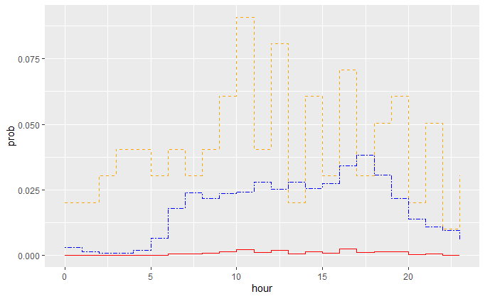

```r
# the probability of a car getting hit by a rock incase it breaks through the security net.
sum(probability_car$t_p_pro_hour)
```

```
[1] 0.02006033
```